# Trafford’s Population Projections

## Projections based on 2022

On June 2025, the ONS released the Population Projections based on the 2022 mid-year estimates. Several projections variants were published. The report below uses the Migration category variant.

### Population Growth

From 2022 to 2032, Trafford’s population is projected to grow 4.3%, an increment of 10,161 people from 236,651 to 246,812.

England’s and Greater Manchester’s population is projected to grow more rapidly than Trafford’s, at 7.8% and 7% respectively.

Looking at broad age categories, the under 16 years Trafford’s population is projected to decrease 9.7%. England’s and Greater Manchester’s under 16 population are also projected to decrease but less than Trafford’s, at -5.8% and -6.7% respectively.

Greater Manchester’s 16-65 population is projected to grow more than England’s, however Trafford’s 16-65 population is projected to grow less than England’s.

Trafford’s population 66 or over is projected to grow but at a lesser rate than Greater Manchester’s, and the rate of growth for both will be less than England’s.

[interactive chart not shown]

Trafford's population estimates

| Year | Under 16 | 16-65 | 66 or over | All ages |
| --- | --- | --- | --- | --- |
| 2022 | 49529 | 147657 | 39465 | 236651 |
| 2023 | 49517 | 149074 | 39734 | 238325 |
| 2024 | 49266 | 150561 | 40118 | 239946 |
| 2025 | 48757 | 151617 | 40537 | 240910 |
| 2026 | 48230 | 152468 | 41006 | 241704 |
| 2027 | 47375 | 153547 | 41501 | 242424 |
| 2028 | 46661 | 154502 | 42048 | 243212 |
| 2029 | 46136 | 155273 | 42696 | 244105 |
| 2030 | 45583 | 155955 | 43391 | 244929 |
| 2031 | 45199 | 156587 | 44035 | 245821 |

[output cut: 1 more lines]

[interactive chart not shown]

### Greater Manchester authorities growth

The populations of Greater Manchester (GM) local authorities will grow at different rates. Salford is projected to have the largest growth among them with 15.2% change and 42,468 more people from 2022 to 2032 and also is one of the local authorities with the largest growth nationally. Bury is projected to have the lowest growth with 2.1% change and 4,058 more people. Trafford will have the 4th lowest growth among GM authorities with 4.3% change and 10,162 more people.

[interactive chart not shown]

### Trafford’s population change by age

The population growth in the population pyramid reflects the growth seen in the broad age categories.

For females from 2022 to 2032, the 45-49 years old group is projected to have the largest increase in number with 1,498 more, whilst the 85-89 years old will have the largest increase in % change with 20.3% change. The 5-9 years old group will have the largest decrease in number with 1,340 less, also the 5-9 years old will have the largest decrease in % change with -20.4% change.

For males, the 45-49 years old group will have the largest increase in number with 1,288 more, whilst the 90+ years old will have the largest increase in % change with 21.6% change. The 5-9 years old group will have the largest decrease in number with 1,340 less, also the 5-9 years old will have the largest decrease in % change with -19.7% change.

Select the tabs below for:

#### Population pyramid

[interactive chart not shown]

#### Difference

| Age Band | Females | Males | Persons | Females | Males | Persons | Females | Males | Persons |
| --- | --- | --- | --- | --- | --- | --- | --- | --- | --- |
| 0-4 | 6334 | 6704 | 13038 | 5980 | 6312 | 12291 | -354 | -392 | -747 |
| 5-9 | 7914 | 8233 | 16147 | 6574 | 6893 | 13466 | -1340 | -1340 | -2681 |
| 10-14 | 8364 | 8845 | 17209 | 7574 | 7984 | 15558 | -790 | -861 | -1651 |
| 15-19 | 6581 | 7057 | 13638 | 7300 | 7755 | 15055 | 719 | 698 | 1417 |
| 20-24 | 5272 | 5415 | 10687 | 5650 | 5993 | 11642 | 378 | 578 | 955 |
| 25-29 | 6159 | 6256 | 12415 | 7257 | 7495 | 14751 | 1098 | 1239 | 2336 |
| 30-34 | 7728 | 6939 | 14667 | 8103 | 7943 | 16047 | 375 | 1004 | 1380 |
| 35-39 | 9055 | 8119 | 17174 | 8981 | 8782 | 17763 | -74 | 663 | 589 |
| 40-44 | 9383 | 8551 | 17934 | 9771 | 9393 | 19163 | 388 | 842 | 1229 |
| 45-49 | 8138 | 7875 | 16013 | 9636 | 9163 | 18798 | 1498 | 1288 | 2785 |

[output cut: 9 more lines]

### Younger populations

In 2032, 22% of people are projected to be aged 18 years and under, down from 25% in 2022, this is above the average for England in 2032 (20%). Infants (aged 0 to 4) will fall from 6% to 5% between 2022 to 2032. Primary school age children (aged 5 to 11 years) will fall from 10% to 8%. Secondary school age children and sixth-form age (aged 12 to 17 years) will stay around the same, at 8%.

Select the tabs below for:

#### 2022 to 2032

[figure not shown]

Source: ONS | @traffordDataLab

#### All years

| Age | 2022 | 2023 | 2024 | 2025 | 2026 | 2027 | 2028 | 2029 | 2030 | 2031 | 2032 | Pop % 2022 | Pop % 2032 | Diff. from 2022 |
| --- | --- | --- | --- | --- | --- | --- | --- | --- | --- | --- | --- | --- | --- | --- |
| 0 | 2278 | 2248 | 2237 | 2231 | 2242 | 2248 | 2272 | 2289 | 2308 | 2329 | 2349 | 0.96 | 0.95 | 71 |
| 1 | 2433 | 2360 | 2319 | 2305 | 2300 | 2311 | 2318 | 2341 | 2358 | 2376 | 2397 | 1.03 | 0.97 | -36 |
| 2 | 2520 | 2530 | 2463 | 2402 | 2387 | 2385 | 2397 | 2404 | 2427 | 2444 | 2462 | 1.06 | 1 | -58 |
| 3 | 2912 | 2616 | 2614 | 2541 | 2471 | 2459 | 2459 | 2472 | 2480 | 2502 | 2519 | 1.23 | 1.02 | -393 |
| 4 | 2895 | 2982 | 2694 | 2672 | 2603 | 2527 | 2518 | 2522 | 2535 | 2543 | 2564 | 1.22 | 1.04 | -331 |
| 5 | 3076 | 2962 | 3041 | 2750 | 2721 | 2656 | 2578 | 2571 | 2577 | 2590 | 2598 | 1.3 | 1.05 | -478 |
| 6 | 3246 | 3152 | 3032 | 3097 | 2810 | 2776 | 2716 | 2635 | 2630 | 2638 | 2650 | 1.37 | 1.07 | -596 |
| 7 | 3137 | 3318 | 3218 | 3085 | 3145 | 2865 | 2829 | 2773 | 2690 | 2686 | 2694 | 1.33 | 1.09 | -443 |
| 8 | 3356 | 3204 | 3375 | 3264 | 3128 | 3185 | 2914 | 2875 | 2824 | 2737 | 2734 | 1.42 | 1.11 | -622 |
| 9 | 3332 | 3428 | 3274 | 3428 | 3314 | 3177 | 3234 | 2970 | 2928 | 2880 | 2790 | 1.41 | 1.13 | -542 |

[output cut: 9 more lines]

### Older populations

People aged 65 an over will increase from 17.7% to 19.1% between 2022 and 2032.

Select the tabs below for:

#### 2022 to 2032

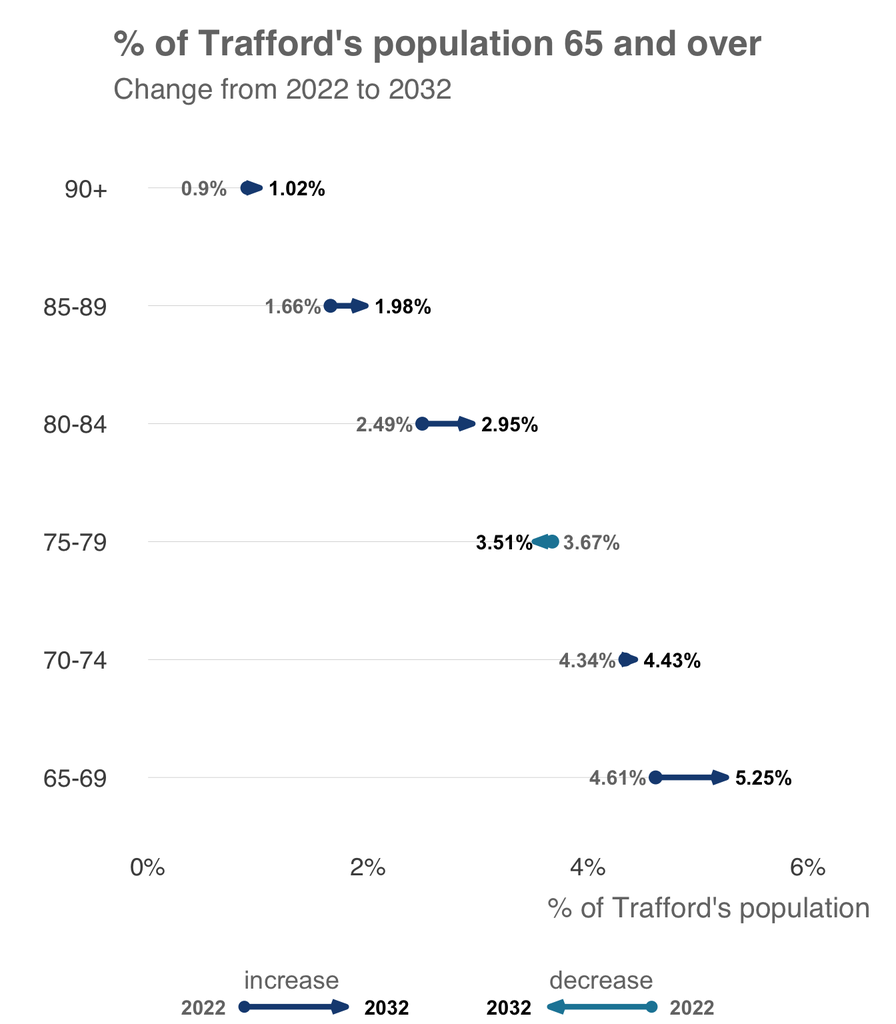

Source: ONS | @traffordDataLab

#### All years

| Age Band | 2022 | 2023 | 2024 | 2025 | 2026 | 2027 | 2028 | 2029 | 2030 | 2031 | 2032 | Pop % 2022 | Pop % 2032 | Diff. from 2022 |
| --- | --- | --- | --- | --- | --- | --- | --- | --- | --- | --- | --- | --- | --- | --- |
| 65-69 | 10914 | 11139 | 11363 | 11575 | 11797 | 12030 | 12315 | 12611 | 12830 | 12954 | 12969 | 4.61 | 5.25 | 2055 |
| 70-74 | 10262 | 9887 | 9766 | 9699 | 9719 | 9849 | 10055 | 10269 | 10478 | 10700 | 10926 | 4.34 | 4.43 | 664 |
| 75-79 | 8691 | 9020 | 9102 | 9220 | 9331 | 8947 | 8642 | 8544 | 8497 | 8533 | 8666 | 3.67 | 3.51 | -25 |
| 80-84 | 5896 | 6002 | 6114 | 6276 | 6432 | 7002 | 7298 | 7382 | 7490 | 7577 | 7280 | 2.49 | 2.95 | 1384 |
| 85-89 | 3923 | 3944 | 4070 | 4085 | 4008 | 3951 | 4062 | 4191 | 4329 | 4450 | 4883 | 1.66 | 1.98 | 960 |
| 90+ | 2134 | 2159 | 2170 | 2190 | 2258 | 2319 | 2385 | 2468 | 2499 | 2497 | 2509 | 0.9 | 1.02 | 375 |